# Report Overview

1. Packages
2. Methods
3. General
4. Task performance
   - Math
   - Stroop
   - CPT
5. Eye tracking

## Packages

**VRAM specific**

A majority of the code used for this analysis is located in */src/Vrama* directory. Several functions included here will eventially be refactored and integrated into the source code directory.

```
The autoreload extension is already loaded. To reload it, use:
  %reload_ext autoreload
```

### Methods

PlotRT(yL,sdL,bars,color,title)

PlotAcc(count,num_correct,num_response,bars,title)

PlotTask(df,task)

GetSubjectData(subjectID)

PlotDistractionOnOff(df_on,df_off,task)

## General

Screening session for subject 19205 occurred on May 24th. Nine blocks (three blocks of each task) were collected, which is maximum amount of task blocks we have been collecting. What is not made clear is the task block order. Each subject completes one block of each task. The task order is then repeated for the remaining six blocks.

|  | subject | date | SessionType | math | axcpt | stroop |
| --- | --- | --- | --- | --- | --- | --- |
| 0 | 19205 | 05_24_2019 | Screening | 3 | 3 | 3 |

## Task performance

For each task type, we show the following:

- Results table
- Reaction time by block
- Performance by block (correct, incorrect, no response)
- Peformance by block (Distraction Off vx Distraction On)

### Math

|  | Subject | Date | SessionType | count | time_s | cnt_button1 | cnt_button3 | num_responses | num_correct | mean_rt | mean_crt_rt | sd_rt | sd_crt_rt |
| --- | --- | --- | --- | --- | --- | --- | --- | --- | --- | --- | --- | --- | --- |
| 0 | 19205 | 05_24_2019_08_56_17 | Screening | 59 | 239.9243 | 37 | 11 | 59 | 26 | 2.057849 | 2.628592 | 3.100363 | 3.643976 |
| 1 | 19205 | 05_24_2019_09_19_19 | Screening | 37 | 239.9583 | 17 | 19 | 37 | 28 | 4.625963 | 4.361215 | 3.091468 | 3.040654 |
| 2 | 19205 | 05_24_2019_09_43_47 | Screening | 44 | 235.9673 | 19 | 14 | 44 | 25 | 3.426336 | 3.603887 | 2.623360 | 2.156784 |

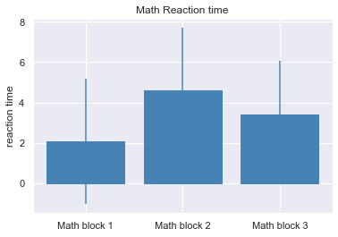

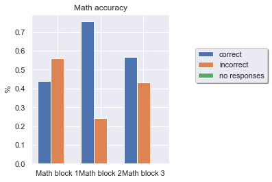

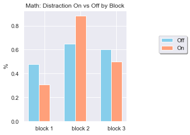

### Stroop

|  | Subject | Date | SessionType | count | time_s | cnt_button1 | cnt_button3 | num_responses | num_correct | mean_rt | mean_crt_rt | sd_rt | sd_crt_rt |
| --- | --- | --- | --- | --- | --- | --- | --- | --- | --- | --- | --- | --- | --- |
| 0 | 19205 | 05_24_2019_08_38_35 | Screening | 87 | 236.1908 | 15 | 20 | 36 | 17 | 1.373473 | 1.331347 | 0.672353 | 0.686779 |
| 1 | 19205 | 05_24_2019_09_03_19 | Screening | 80 | 236.0488 | 32 | 39 | 73 | 51 | 1.297126 | 1.315971 | 0.390916 | 0.396421 |
| 2 | 19205 | 05_24_2019_09_28_36 | Screening | 79 | 236.0566 | 40 | 29 | 69 | 48 | 1.189223 | 1.211385 | 0.558750 | 0.544111 |

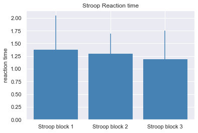

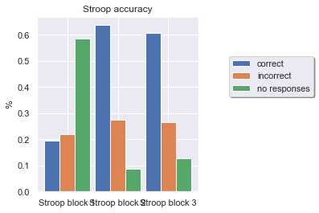

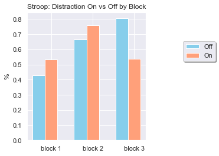

#### CPT

|  | Subject | Date | SessionType | count | time_s | cnt_button1 | cnt_button3 | num_responses | num_correct | mean_rt | mean_crt_rt | sd_rt | sd_crt_rt |
| --- | --- | --- | --- | --- | --- | --- | --- | --- | --- | --- | --- | --- | --- |
| 0 | 19205 | 05_24_2019_08_44_24 | Screening | 100 | 232.5524 | 48 | 11 | 60 | 50 | 0.653527 | 0.664497 | 0.280798 | 0.286075 |
| 1 | 19205 | 05_24_2019_09_12_35 | Screening | 103 | 232.5310 | 56 | 22 | 79 | 68 | 0.589773 | 0.552996 | 0.342849 | 0.179649 |
| 2 | 19205 | 05_24_2019_09_36_20 | Screening | 100 | 232.5962 | 51 | 15 | 69 | 65 | 0.541086 | 0.538277 | 0.232138 | 0.235093 |

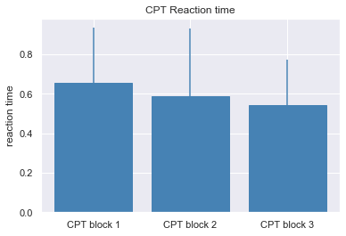

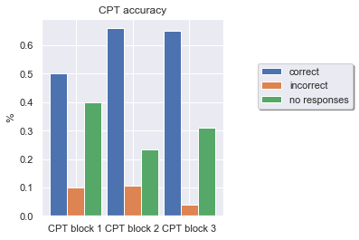

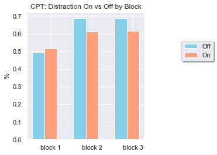

## Eye tracking

#### Overall view duration table

**Table variables**

- Task duration
- % time gaze on distractor objects
- % time gaze on other environment objects
- % time gaze on whiteboard
- Time (ms) gaze on distractor objects
- Time (ms) gaze on other environment objects
- Time (ms) gaze on whiteboard
- List of all gaze objects
- List of all distractor objects

|  | Task_duration(min) | View_duration_distractor(%) | View_duration_other(%) | View_duration_whiteboard(%) | View_duration_distractor(ms) | View_duration_other(ms) | View_duration_whiteboard(ms) | Object_list | Distractor_list |
| --- | --- | --- | --- | --- | --- | --- | --- | --- | --- |
| 0 | 36.343655 | 1.709915 | 24.356625 | 73.93346 | 37286.7346 | 531125.2677 | 1.612207e+06 | [Null, FrontWall, GroundExterior, Kevin, White... | [nan, iPhoneX, Pedestrian, BusSouth, Child009,... |

```
array([1.7099149188986884, 24.356625185523068, 73.93345989557824],
      dtype=object)
```

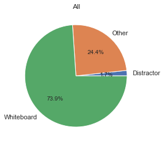

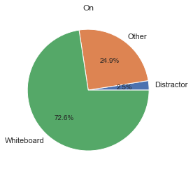

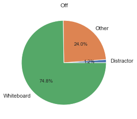

|  | distractors |
| --- | --- |
| 1 | iPhoneX |
| 2 | Pedestrian |
| 3 | BusSouth |
| 4 | Child009 |
| 5 | Child002 |
| 6 | Child006 |
| 7 | Child001 |
| 8 | BusNorth |
| 9 | iPhoneX2 |
| 10 | NewestTeacher |
| 11 | Child008 |
| 12 | Child005 |
| 13 | Car |

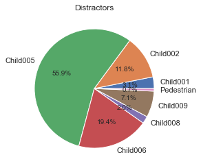

|  | classroom objects |
| --- | --- |
| 1 | FrontWall |
| 2 | GroundExterior |
| 3 | Kevin |
| 4 | WhiteBoardWithDisplay |
| 5 | UCDavisTeacher |
| 6 | Whiteboard1 |
| 7 | CeilingCollider |
| 8 | Quinn |
| 9 | printer |
| 10 | cabinet002 |
| 11 | Houses |
| 12 | LeftWall |
| 13 | Pedestrian |
| 14 | Bus002 |
| 15 | wallUnit001 |
| 16 | Lightposts |
| 17 | globe_ball |
| 18 | Xia |
| 19 | ProjectorPodium |
| 20 | Cameron |
| 21 | ClassroomDoor |
| 22 | Taylor |
| 23 | bulletinboard002 |
| 24 | RightWallCollider |
| 25 | Child006 |
| 26 | Bailey |
| 27 | computermoniter003 |
| 28 | Alexander |
| 29 | Noah |
| 30 | Keyboard2 |
| 31 | Henry |
| 32 | TeachersChair |
| 33 | Desk010_Notebook_Open |
| 34 | Desk008_Notebook_Open |
| 35 | computermoniter002 |
| 36 | computermoniter004 |
| 37 | Zayden |
| 38 | Child009 |
| 39 | BackWallCollider |
| 40 | bulletinboard006 |
| 41 | Chair_GRP005 |
| 42 | Chair_GRP009 |
| 43 | Chair_GRP008 |
| 44 | Chair_GRP007 |
| 45 | bulletinboard005 |
| 46 | bulletinboard003 |
| 47 | Bus001 |
| 48 | cabinet001 |
| 49 | Child002 |
| 50 | Child001 |
| 51 | Child005 |
| 52 | sedan_silver_prius |
| 53 | Jordan |
| 54 | bulletinboard004 |
| 55 | Child008 |
| 56 | bookcase0001 |
| 57 | TeachersDeskPapers |

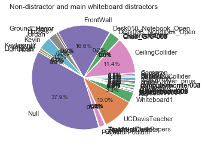

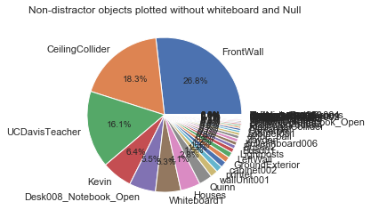

Table output organized by object type

|  | Name | Duration | Type | Percentage |
| --- | --- | --- | --- | --- |
| 0 | Child008 | 7.377502e+02 | distractor | 0.000338 |
| 1 | Child009 | 2.653759e+03 | distractor | 0.001217 |
| 2 | Child006 | 7.216191e+03 | distractor | 0.003309 |
| 3 | Child005 | 2.085681e+04 | distractor | 0.009565 |
| 4 | Child002 | 4.388061e+03 | distractor | 0.002012 |
| 5 | Child001 | 1.170886e+03 | distractor | 0.000537 |
| 6 | Pedestrian | 2.632775e+02 | distractor | 0.000121 |
| 7 | cabinet001 | 1.548599e+03 | other | 0.000710 |
| 8 | Quinn | 9.251466e+03 | other | 0.004243 |
| 9 | RightWallCollider | 1.164527e+03 | other | 0.000534 |
| 10 | Taylor | 3.930410e+02 | other | 0.000180 |
| 11 | TeachersChair | 2.902142e+02 | other | 0.000133 |
| 12 | TeachersDeskPapers | 1.196910e+01 | other | 0.000005 |
| 13 | UCDavisTeacher | 5.312409e+04 | other | 0.024362 |
| 14 | Whiteboard1 | 1.746041e+04 | other | 0.008007 |
| 15 | Xia | 2.174202e+02 | other | 0.000100 |
| 16 | Zayden | 2.269725e+03 | other | 0.001041 |
| 17 | bookcase0001 | 1.126983e+02 | other | 0.000052 |
| 18 | bulletinboard002 | 8.629303e+02 | other | 0.000396 |
| 19 | bulletinboard003 | 7.978900e+00 | other | 0.000004 |
| 20 | printer | 4.353711e+03 | other | 0.001997 |
| 21 | ProjectorPodium | 1.065806e+03 | other | 0.000489 |
| 22 | globe_ball | 1.965421e+03 | other | 0.000901 |
| 23 | computermoniter004 | 1.595870e+01 | other | 0.000007 |
| 24 | computermoniter003 | 2.242332e+02 | other | 0.000103 |
| 25 | computermoniter002 | 1.805430e+02 | other | 0.000083 |
| 26 | bulletinboard004 | 8.156613e+02 | other | 0.000374 |
| 27 | bulletinboard005 | 3.141599e+02 | other | 0.000144 |
| 28 | bulletinboard006 | 2.322917e+03 | other | 0.001065 |
| 29 | cabinet002 | 4.232688e+03 | other | 0.001941 |
| 30 | Alexander | 1.240729e+03 | other | 0.000569 |
| 31 | Lightposts | 2.998924e+03 | other | 0.001375 |
| 32 | Noah | 1.671988e+02 | other | 0.000077 |
| 33 | BackWallCollider | 2.763301e+02 | other | 0.000127 |
| 34 | Bailey | 1.199860e+01 | other | 0.000006 |
| 35 | Bus001 | 2.539783e+03 | other | 0.001165 |
| 36 | Bus002 | 2.440566e+03 | other | 0.001119 |
| 37 | Cameron | 1.506145e+03 | other | 0.000691 |
| 38 | CeilingCollider | 6.039454e+04 | other | 0.027696 |
| 39 | Chair_GRP005 | 2.193990e+01 | other | 0.000010 |
| 40 | Chair_GRP007 | 1.994550e+01 | other | 0.000009 |
| 41 | Chair_GRP008 | 1.231584e+02 | other | 0.000056 |
| 42 | Chair_GRP009 | 2.094380e+01 | other | 0.000010 |
| 43 | ClassroomDoor | 5.043988e+02 | other | 0.000231 |
| 44 | Desk008_Notebook_Open | 1.820253e+04 | other | 0.008347 |
| 45 | Desk010_Notebook_Open | 8.591763e+02 | other | 0.000394 |
| 46 | FrontWall | 8.835492e+04 | other | 0.040518 |
| 47 | GroundExterior | 3.940247e+03 | other | 0.001807 |
| 48 | Henry | 3.990100e+01 | other | 0.000018 |
| 49 | Houses | 1.367097e+04 | other | 0.006269 |
| 50 | Jordan | 1.007307e+02 | other | 0.000046 |
| 51 | Kevin | 2.115358e+04 | other | 0.009701 |
| 52 | Keyboard2 | 1.296580e+01 | other | 0.000006 |
| 53 | LeftWall | 3.848417e+03 | other | 0.001765 |
| 54 | sedan_silver_prius | 1.118252e+02 | other | 0.000051 |
| 55 | Null | 2.012514e+05 | other | 0.092291 |
| 56 | wallUnit001 | 5.105864e+03 | other | 0.002341 |
| 57 | WhiteBoardWithDisplay | 1.612207e+06 | white board | 0.739335 |

Table output ordered high-to-low by view duration

|  | Name | Duration | Type | Percentage |
| --- | --- | --- | --- | --- |
| 0 | WhiteBoardWithDisplay | 1.612207e+06 | white board | 0.739335 |
| 1 | Null | 2.012514e+05 | other | 0.092291 |
| 2 | FrontWall | 8.835492e+04 | other | 0.040518 |
| 3 | CeilingCollider | 6.039454e+04 | other | 0.027696 |
| 4 | UCDavisTeacher | 5.312409e+04 | other | 0.024362 |
| 5 | Kevin | 2.115358e+04 | other | 0.009701 |
| 6 | Child005 | 2.085681e+04 | distractor | 0.009565 |
| 7 | Desk008_Notebook_Open | 1.820253e+04 | other | 0.008347 |
| 8 | Whiteboard1 | 1.746041e+04 | other | 0.008007 |
| 9 | Houses | 1.367097e+04 | other | 0.006269 |
| 10 | Quinn | 9.251466e+03 | other | 0.004243 |
| 11 | Child006 | 7.216191e+03 | distractor | 0.003309 |
| 12 | wallUnit001 | 5.105864e+03 | other | 0.002341 |
| 13 | Child002 | 4.388061e+03 | distractor | 0.002012 |
| 14 | printer | 4.353711e+03 | other | 0.001997 |
| 15 | cabinet002 | 4.232688e+03 | other | 0.001941 |
| 16 | GroundExterior | 3.940247e+03 | other | 0.001807 |
| 17 | LeftWall | 3.848417e+03 | other | 0.001765 |
| 18 | Lightposts | 2.998924e+03 | other | 0.001375 |
| 19 | Child009 | 2.653759e+03 | distractor | 0.001217 |
| 20 | Bus001 | 2.539783e+03 | other | 0.001165 |
| 21 | Bus002 | 2.440566e+03 | other | 0.001119 |
| 22 | bulletinboard006 | 2.322917e+03 | other | 0.001065 |
| 23 | Zayden | 2.269725e+03 | other | 0.001041 |
| 24 | globe_ball | 1.965421e+03 | other | 0.000901 |
| 25 | cabinet001 | 1.548599e+03 | other | 0.000710 |
| 26 | Cameron | 1.506145e+03 | other | 0.000691 |
| 27 | Alexander | 1.240729e+03 | other | 0.000569 |
| 28 | Child001 | 1.170886e+03 | distractor | 0.000537 |
| 29 | RightWallCollider | 1.164527e+03 | other | 0.000534 |
| 30 | ProjectorPodium | 1.065806e+03 | other | 0.000489 |
| 31 | bulletinboard002 | 8.629303e+02 | other | 0.000396 |
| 32 | Desk010_Notebook_Open | 8.591763e+02 | other | 0.000394 |
| 33 | bulletinboard004 | 8.156613e+02 | other | 0.000374 |
| 34 | Child008 | 7.377502e+02 | distractor | 0.000338 |
| 35 | ClassroomDoor | 5.043988e+02 | other | 0.000231 |
| 36 | Taylor | 3.930410e+02 | other | 0.000180 |
| 37 | bulletinboard005 | 3.141599e+02 | other | 0.000144 |
| 38 | TeachersChair | 2.902142e+02 | other | 0.000133 |
| 39 | BackWallCollider | 2.763301e+02 | other | 0.000127 |
| 40 | Pedestrian | 2.632775e+02 | distractor | 0.000121 |
| 41 | computermoniter003 | 2.242332e+02 | other | 0.000103 |
| 42 | Xia | 2.174202e+02 | other | 0.000100 |
| 43 | computermoniter002 | 1.805430e+02 | other | 0.000083 |
| 44 | Noah | 1.671988e+02 | other | 0.000077 |
| 45 | Chair_GRP008 | 1.231584e+02 | other | 0.000056 |
| 46 | bookcase0001 | 1.126983e+02 | other | 0.000052 |
| 47 | sedan_silver_prius | 1.118252e+02 | other | 0.000051 |
| 48 | Jordan | 1.007307e+02 | other | 0.000046 |
| 49 | Henry | 3.990100e+01 | other | 0.000018 |
| 50 | Chair_GRP005 | 2.193990e+01 | other | 0.000010 |
| 51 | Chair_GRP009 | 2.094380e+01 | other | 0.000010 |
| 52 | Chair_GRP007 | 1.994550e+01 | other | 0.000009 |
| 53 | computermoniter004 | 1.595870e+01 | other | 0.000007 |
| 54 | Keyboard2 | 1.296580e+01 | other | 0.000006 |
| 55 | Bailey | 1.199860e+01 | other | 0.000006 |
| 56 | TeachersDeskPapers | 1.196910e+01 | other | 0.000005 |
| 57 | bulletinboard003 | 7.978900e+00 | other | 0.000004 |